# QuEST coding workshop day 2: tidyverse introduction

8/20/2021

## tidyverse overview

From the website:

“The tidyverse is an opinionated collection of R packages designed for data science. All packages share an underlying design philosophy, grammar, and data structures.”

The “core” tidyverse packages are the ones automatically install/loaded:

```r
library(tidyverse)
```

They form a [complete workflow](https://www.tidyverse.org/packages/) for writing most R programs:

- `readr` for reading/writing rectangular data
- `tidyr` for cleaning and organizing data
- `dplyr` and `purrr` for manipulating and summarizing
- `forcats` and `stringr` for special operations on factors/strings

In addition to these core packages, other more specific packages are considered part of the “extended” tidyverse. These packages need to be installed/loaded independently.

### Learning resources

- [Cheatsheets](https://www.rstudio.com/resources/cheatsheets/) are a great way to learn a package quickly. I also like to use them to learn a package while working. I’ll pull up the package I want to learn, and try to find ways to use different functions from it for whatever I’m doing.
- [R for Data Science](https://r4ds.had.co.nz/index.html) (R4DS) can be good for all levels, and centers around the tidyverse. It starts very gently and assumes almost no R knowledge. There are also exercises and solutions available.
- [Advanced R](https://adv-r.hadley.nz/index.html) is a more general programming guide, but draws heavily from tidyverse packages.

## tibbles and tidyr

The most fundamental data structure for tidyverse is a modernization of the dataframe. The most important differences are clearer printing and more flexible column names.

```r
(dat <- starwars)
```

```
## # A tibble: 87 x 14
##    name    height  mass hair_color  skin_color eye_color birth_year sex   gender
##    <chr>    <int> <dbl> <chr>       <chr>      <chr>          <dbl> <chr> <chr>
##  1 Luke S~    172    77 blond       fair       blue            19   male  mascu~
##  2 C-3PO      167    75 <NA>        gold       yellow         112   none  mascu~
##  3 R2-D2       96    32 <NA>        white, bl~ red             33   none  mascu~
##  4 Darth ~    202   136 none        white      yellow          41.9 male  mascu~
##  5 Leia O~    150    49 brown       light      brown           19   fema~ femin~
##  6 Owen L~    178   120 brown, grey light      blue            52   male  mascu~
##  7 Beru W~    165    75 brown       light      blue            47   fema~ femin~
##  8 R5-D4       97    32 <NA>        white, red red             NA   none  mascu~
##  9 Biggs ~    183    84 black       light      brown           24   male  mascu~
## 10 Obi-Wa~    182    77 auburn, wh~ fair       blue-gray       57   male  mascu~
## # ... with 77 more rows, and 5 more variables: homeworld <chr>, species <chr>,
## #   films <list>, vehicles <list>, starships <list>
```

### Creating tibbles

`read_*` always returns a tibble. Creating tibbles from scratch can be done similar to `data.frame`:

```r
tibble(x = 1:5, y = LETTERS[1:5], z = x^2)
```

```
## # A tibble: 5 x 3
##       x y         z
##   <int> <chr> <dbl>
## 1     1 A         1
## 2     2 B         4
## 3     3 C         9
## 4     4 D        16
## 5     5 E        25
```

or with `tribble`

```r
tribble(
  ~x, ~y,
  1, 'A',
  2, 'B',
  3, 'C'
)
```

```
## # A tibble: 3 x 2
##       x y
##   <dbl> <chr>
## 1     1 A
## 2     2 B
## 3     3 C
```

```
## # A tibble: 50 x 2
##    speed  dist
##    <dbl> <dbl>
##  1     4     2
##  2     4    10
##  3     7     4
##  4     7    22
##  5     8    16
##  6     9    10
##  7    10    18
##  8    10    26
##  9    10    34
## 10    11    17
## # ... with 40 more rows
```

```
## # A tibble: 3 x 2
##   name  value
##   <chr> <dbl>
## 1 a         1
## 2 b         2
## 3 c         3
```

You can largely use tibbles and dataframes interchangeably (functions that say they work with one will work with the other), so I’ll just call them dataframes from now on. See the vignette for more features and differences from regular dataframes

```
vignette('tibble')
```

### Tidy data

[R for Data Science](https://r4ds.had.co.nz/tidy-data.html) gives three rules for tidy data:

1. Each variable has its own column
2. Each observation has its own row
3. Each value must have its own cell

The `tidyr` package contains functions for making data tidy. For example, suppose you are given some data from a field survey.

```r
survey <- tibble(
  present_yes = sample(c('yes', NA), 15, replace = TRUE),
  present_no = ifelse(is.na(present_yes), 'no', NA)
)

survey
```

```
## # A tibble: 15 x 2
##    present_yes present_no
##    <chr>       <chr>
##  1 <NA>        no
##  2 yes         <NA>
##  3 <NA>        no
##  4 <NA>        no
##  5 <NA>        no
##  6 <NA>        no
##  7 <NA>        no
##  8 <NA>        no
##  9 <NA>        no
## 10 <NA>        no
## 11 yes         <NA>
## 12 <NA>        no
## 13 yes         <NA>
## 14 <NA>        no
## 15 yes         <NA>
```

Someone has spread a single variable over two columns, causing lots of blank spaces in the data. This may have been more convenient in the field, but programming with the data as-is will be a bit difficult. Thankfully, conversion to tidy format is easy.

```r
unite(survey, 'present', present_yes, present_no, na.rm = TRUE)
```

```
## # A tibble: 15 x 1
##    present
##    <chr>
##  1 no
##  2 yes
##  3 no
##  4 no
##  5 no
##  6 no
##  7 no
##  8 no
##  9 no
## 10 no
## 11 yes
## 12 no
## 13 yes
## 14 no
## 15 yes
```

Here, we have used `unite`, which pastes two or more columns of strings into a single column, while removing the `NA`s.

Another nice tidyr use is to drop rows which contain an `NA`, possibly only in specific columns.

```r
nrow(dat)
```

```
## [1] 87
```

```r
nrow(drop_na(dat)) # drop all rows with an NA
```

```
## [1] 6
```

```r
nrow(drop_na(dat, birth_year)) # only rows with NA in "birth_year"
```

```
## [1] 43
```

## Dplyr

The `dplyr` package is great for performing seemingly endless operations on dataframes. Just like in base R, we can subset a dataframe by rows or columns:

```r
## select specific cols
dat[,c(2, 6)]
select(dat, height, eye_color)

dat[,1:5]
select(dat, name:skin_color)

## select last 5 rows
tail(dat, 5)
slice_tail(dat, n = 5)

## all cols with an underscore
dat[, which(str_detect(colnames(dat), '_'))]
select(dat, contains('_'))
```

More complex slicing and subsetting is possible

```r
## select cols conditionally
select(dat, where(is.double))
select(dat, !last_col() & ends_with('s'))

## slice rows conditionally (filtering)
filter(dat, eye_color == 'blue')
```

### The pipe operator

Notice that most tidyverse functions are verbs or adverbs (coding is, after all, just giving instructions). There is a special operator, the *pipe* operator, which allows these commands to be chained together!

```r
dat |> # start of chain is the data
  filter(eye_color == 'blue') |> # each step takes the previous result
  select(height:species) |> # and does a new thing to it
  drop_na() |>
  slice_sample(n = 1000, replace = TRUE)
```

```
## # A tibble: 1,000 x 10
##    height  mass hair_color  skin_color eye_color birth_year sex    gender
##     <int> <dbl> <chr>       <chr>      <chr>          <dbl> <chr>  <chr>
##  1    165    75 brown       light      blue            47   female feminine
##  2    166    50 black       yellow     blue            40   female feminine
##  3    166    50 black       yellow     blue            40   female feminine
##  4    165    75 brown       light      blue            47   female feminine
##  5    172    77 blond       fair       blue            19   male   masculine
##  6    178   120 brown, grey light      blue            52   male   masculine
##  7    175    79 none        light      blue            37   male   masculine
##  8    172    77 blond       fair       blue            19   male   masculine
##  9    172    77 blond       fair       blue            19   male   masculine
## 10    188    84 blond       fair       blue            41.9 male   masculine
## # ... with 990 more rows, and 2 more variables: homeworld <chr>, species <chr>
```

`x |> f |> g` is the same as `g(f(x))`; however, when you string alot of functions together piping makes things more readable.

### Mutate, summarize, and count

```r
dat |>
  mutate(mass_per_cm = mass / height) # divide mass column by height column
```

```
## # A tibble: 87 x 15
##    name    height  mass hair_color  skin_color eye_color birth_year sex   gender
##    <chr>    <int> <dbl> <chr>       <chr>      <chr>          <dbl> <chr> <chr>
##  1 Luke S~    172    77 blond       fair       blue            19   male  mascu~
##  2 C-3PO      167    75 <NA>        gold       yellow         112   none  mascu~
##  3 R2-D2       96    32 <NA>        white, bl~ red             33   none  mascu~
##  4 Darth ~    202   136 none        white      yellow          41.9 male  mascu~
##  5 Leia O~    150    49 brown       light      brown           19   fema~ femin~
##  6 Owen L~    178   120 brown, grey light      blue            52   male  mascu~
##  7 Beru W~    165    75 brown       light      blue            47   fema~ femin~
##  8 R5-D4       97    32 <NA>        white, red red             NA   none  mascu~
##  9 Biggs ~    183    84 black       light      brown           24   male  mascu~
## 10 Obi-Wa~    182    77 auburn, wh~ fair       blue-gray       57   male  mascu~
## # ... with 77 more rows, and 6 more variables: homeworld <chr>, species <chr>,
## #   films <list>, vehicles <list>, starships <list>, mass_per_cm <dbl>
```

This function, like many others, is often useful to apply separately to different *groups* in the data. Suppose we want to assign each character a unique id based on their homeworld:

```r
dat |>
  group_by(homeworld) |>
  mutate(world_id = str_c(homeworld, '_', 1:n())) |> # n() is short for group size
  pull(world_id) # convert column "world_id" to a vector
```

```
##  [1] "Tatooine_1"       "Tatooine_2"       "Naboo_1"          "Tatooine_3"
##  [5] "Alderaan_1"       "Tatooine_4"       "Tatooine_5"       "Tatooine_6"
##  [9] "Tatooine_7"       "Stewjon_1"        "Tatooine_8"       "Eriadu_1"
## [13] "Kashyyyk_1"       "Corellia_1"       "Rodia_1"          "Nal Hutta_1"
## [17] "Corellia_2"       "Bestine IV_1"     NA                 "Naboo_2"
## [21] "Kamino_1"         NA                 "Trandosha_1"      "Socorro_1"
## [25] "Bespin_1"         "Mon Cala_1"       "Chandrila_1"      NA
## [29] "Endor_1"          "Sullust_1"        NA                 "Cato Neimoidia_1"
## [33] "Coruscant_1"      "Naboo_3"          "Naboo_4"          "Naboo_5"
## [37] "Naboo_6"          "Toydaria_1"       "Malastare_1"      "Naboo_7"
## [41] "Tatooine_9"       "Dathomir_1"       "Ryloth_1"         "Ryloth_2"
## [45] "Vulpter_1"        "Troiken_1"        "Tund_1"           "Haruun Kal_1"
## [49] "Cerea_1"          "Glee Anselm_1"    "Iridonia_1"       "Coruscant_2"
## [53] "Iktotch_1"        "Quermia_1"        "Dorin_1"          "Champala_1"
## [57] "Naboo_8"          "Naboo_9"          "Tatooine_10"      "Geonosis_1"
## [61] "Mirial_1"         "Mirial_2"         "Naboo_10"         "Serenno_1"
## [65] "Alderaan_2"       "Concord Dawn_1"   "Zolan_1"          "Ojom_1"
## [69] "Kamino_2"         "Kamino_3"         "Coruscant_3"      "Aleen Minor_1"
## [73] NA                 "Skako_1"          "Muunilinst_1"     "Shili_1"
## [77] "Kalee_1"          "Kashyyyk_2"       "Alderaan_3"       "Umbara_1"
## [81] "Utapau_1"         NA                 NA                 NA
## [85] NA                 NA                 "Naboo_11"
```

Grouping is frequently used with `summarize`. Summarizing is a form of reduction; it takes a (grouped) dataframe and returns a new dataframe with one row per group:

```r
dat |>
  group_by(gender) |>
  drop_na(height) |> # remove NAs from height for mean and sd
  summarize(m_height = mean(height), sd_height = sd(height))
```

```
## # A tibble: 3 x 3
##   gender    m_height sd_height
##   <chr>        <dbl>     <dbl>
## 1 feminine      165.     23.6
## 2 masculine     177.     37.6
## 3 <NA>          181.      2.89
```

A more complex example, grouping by two groups, then simulating a distribution for `mass`, based on the observations from each group.

```r
mass_sim <- dat |>
  drop_na(mass) |>
  group_by(eye_color, hair_color) |> # notice the number of groups is printed
  summarize(
    mass_boot = list(sample(mass, 1000, replace = TRUE) + rnorm(1000))
  ) |>
  unnest(mass_boot) # un-collapses the list by repeating the other rows
```

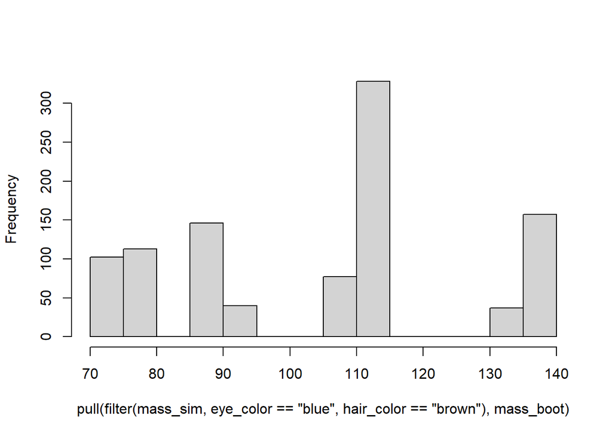

```r
## make a histogram for one group
mass_sim |>
  filter(eye_color == 'blue', hair_color == 'brown') |>
  pull(mass_boot) |>
  hist(breaks = 20, main = '')
```

Here we have used the tidyr function `unnest`, which “expands” a column of lists (a list of lists, really) into a longer column with each entry in each list as a new row.

Finally, the `count` function is for the common summarizing task of counting groups:

```r
count(dat, homeworld, sort = TRUE)
```

```
## # A tibble: 49 x 2
##    homeworld     n
##    <chr>     <int>
##  1 Naboo        11
##  2 Tatooine     10
##  3 <NA>         10
##  4 Alderaan      3
##  5 Coruscant     3
##  6 Kamino        3
##  7 Corellia      2
##  8 Kashyyyk      2
##  9 Mirial        2
## 10 Ryloth        2
## # ... with 39 more rows
```

Count group cominations by providing $>1$ column name, and use `add_count` to add the counts to the existing data.

### Going further

- The R4DS book has some exercises for cleaning and manipulating data in Chapters 5, 10-13, and 16.
- There are several vignettes that cover advanced dplyr concepts, which I’ve found useful. Check out `vignette('colwise')` for applying dplyr functions to many columns at once, `vignette('two-table')` for various ways to combine dataframes, and `vignette('programming')` to learn more about working with *tidy evaluation*, the magic system underlying many tidyverse functions. Or, find all vignettes [here](https://dplyr.tidyverse.org/articles/index.html).

## Some other important concepts

### Pivoting

Recall that tidy data is supposed to have one column per variable, and one row per observation. As we will see soon, plotting is one case where the ambiguity of “variable” and “observation” matters. For this and other cases, there are ways to *pivot* the data, changing the context of variables and observations.

```r
x <- tribble(
  ~A, ~B, ~C,
  1, 2, 3,
  4, 5, 6
)

x
```

```
## # A tibble: 2 x 3
##       A     B     C
##   <dbl> <dbl> <dbl>
## 1     1     2     3
## 2     4     5     6
```

```r
pivot_longer(x, everything())
```

```
## # A tibble: 6 x 2
##   name  value
##   <chr> <dbl>
## 1 A         1
## 2 B         2
## 3 C         3
## 4 A         4
## 5 B         5
## 6 C         6
```

An example with data, counting how many times each color appears anywhere:

```r
dat |>
  pivot_longer(
    hair_color:eye_color,
    names_to='attribute',
    values_to='color'
  ) |>
  count(color)
```

```
## # A tibble: 44 x 2
##    color             n
##    <chr>         <int>
##  1 auburn            1
##  2 auburn, grey      1
##  3 auburn, white     1
##  4 black            23
##  5 blond             3
##  6 blonde            1
##  7 blue             21
##  8 blue-gray         1
##  9 blue, grey        2
## 10 brown            43
## # ... with 34 more rows
```

Here, since we want to count colors across several columns, we pivot these columns into a single column and then `count` it.